# Using ThermStats to calculate statistics for thermal images

Rebecca A. Senior

06 December, 2018

# Summary

`ThermStats` is designed for biologists using thermography to quantify thermal heterogeneity. It uses the `Thermimage` package (Tattersall, 2017) to batch process data from FLIR thermal cameras, and takes inspiration from FRAGSTATS (McGarigal et al., 2012), `SDMTools` (VanDerWal et al., 2014), Faye et al. (2016) and Shi et al. (2016) to facilitate the calculation of various metrics of thermal heterogeneity for any gridded temperature data.

The package is available to download from GitHub using `devtools`:

```r
devtools::install_github("rasenior/ThermStats")
library(ThermStats)
```

Once loaded, the code below can be followed step-by-step.

# Extracting raw data

Data are extracted from FLIR images using `batch_extract`. This is a batch implementation of the `readflirJPG` function from `Thermimage`. It requires only the path to the directory of FLIR thermal images, and the freely available external software [‘Exiftool’](https://www.sno.phy.queensu.ca/~phil/exiftool/). Besides raw data, this step also retrieves camera-specific calibration parameters which are required later to convert raw data to temperature values.

```r
# Batch extract thermal images included in ThermStats installation
flir_raw <-
    batch_extract(in_dir = system.file("extdata",
                                       package = "ThermStats"),
                  write_results = FALSE)
```

# Converting raw data to temperature

Raw data are encoded in each thermal image as a 16 bit analog-to-digital signal, which represents the radiance received by the infrared sensor. The function `batch_convert` converts these raw data to temperature values using equations from infrared thermography, via a batch implementation of the function `raw2temp` in `Thermimage`. It uses the calibration constants extracted in `batch_extract` and environmental parameters defined by the user:

- Emissivity = the amount of radiation emitted by a particular object, for a given temperature.
- Object distance = the distance between the camera and the object of interest.
- Reflected apparent temperature = thermal radiation that originates from other objects and is reflected by the object of interest.
- Atmospheric temperature = the temperature of the atmosphere.
- Relative humidity = the relative humidity of the atmosphere.

```r
# Define raw data
raw_dat <- flir_raw$raw_dat
# Define camera calibration constants dataframe
camera_params <- flir_raw$camera_params
# Define metadata
metadata <- flir_metadata
# Create vector denoting the position of each photo within metadata
photo_index <- match(names(raw_dat),
                     metadata$photo_no)
# Batch convert
flir_converted <-
    batch_convert(
        raw_dat = raw_dat,
        # Emissivity = mean of range in Scheffers et al. 2017
        E = mean(c(0.982,0.99)),
        # Object distance = hypotenuse of right triangle where
        # vertical side is 1.3 m (breast height) & angle down is 45°
        OD = (sqrt(2))*1.3,
        # Apparent reflected temperature & atmospheric temperature =
        # atmospheric temperature measured in the field
        RTemp = metadata$atm_temp[photo_index],
        ATemp = metadata$atm_temp[photo_index],
        # Relative humidity = relative humidity measured in the field
        RH = metadata$rel_humidity[photo_index],
        # Calibration constants from 'batch_extract'
        PR1 = camera_params[,"PlanckR1"],
        PB = camera_params[,"PlanckB"],
        PF = camera_params[,"PlanckF"],
        PO = camera_params[,"PlanckO"],
        PR2 = camera_params[,"PlanckR2"],
        # Whether to write results or just return
        write_results = FALSE)
```

# Calculating thermal statistics

Statistics can be calculated for individual thermal images (in a matrix or raster format), or across multiple images within a specified grouping. The latter is useful for sampling designs where multiple images are collected at each sampling event to capture temperature across a wider sampling unit, such as a plot. In either case, statistics can include summary statistics specified by the user – for example, mean, minimum and maximum – as well as thermal connectivity (based on the climate connectivity measure of McGuire et al., 2016) and spatial statistics for hot and cold spots, identified using the G* variant of the Getis-Ord local statistic (Getis and Ord, 1996).

For an individual image, `get_stats` requires the user to specify the image and the desired statistics. Statistics can be calculated for geographic temperature data, in which case the user should also define the extent and projection of the data.

```r
flir_stats <-
    get_stats(
        # The temperature dataset
        img = flir_converted$`8565`,
        # The ID of the dataset
        id = "8565",
        # Whether or not to calculate thermal connectivity
        calc_connectivity = FALSE,
        # Whether or not to identify hot and cold spots
        patches = TRUE,
        # The image projection (only relevant for geographic data)
        img_proj = NULL,
        # The image extent (only relevant for geographic data)
        img_extent = NULL,
        # The data to return
        return_vals = c("df", # Temperature data as dataframe
                        "patches", # Patch outlines
                        "pstats"), # Patch statistics dataframe
        # The summary statistics of interest
        sum_stats = c("median", "SHDI",
                      "perc_5", "perc_95"))
```

For grouped images, `stats_by_group` requires the user to supply a list of matrices or a raster stack, and (optionally) the metadata and the name of the variable in the metadata that defines the grouping. Table 1 shows the metadata used in the code snippet, where photo number (‘photo_no’) defines individual temperature matrices, and the replicate identity (‘rep_id’) defines the grouping of photos. There are two replicates, ‘T7P1’ and ‘T7P2’, and each has two associated photos.

Table 1: Example metadata denoting the grouping (‘rep_id’) of different thermal images. Statistics can be calculated over multiple images within a group, using the function `stats_by_group`.

| photo_no | rep_id | atm_temp | rel_humidity |
| --- | --- | --- | --- |
| 8565 | T7P1 | 24.00 | 96 |
| 8583 | T7P1 | 24.00 | 96 |
| 8589 | T7P2 | 23.25 | 98 |
| 8613 | T7P2 | 23.50 | 96 |

By default, both `get_stats` and `stats_by_group` return a dataframe with patch statistics (Table 2) for each image or group, respectively.

Table 2: A snippet of hot spot patch statistics returned by `stats_by_group`, which implements `get_stats` within groups.

| img_median | img_perc_5 | img_perc_95 | img_SHDI | hot_shape_index | hot_aggregation |
| --- | --- | --- | --- | --- | --- |
| 23.5 | 23 | 24.5 | 1.16 | 7.54 | 0.895 |
| 24.0 | 23 | 25.0 | 1.68 | 7.80 | 0.855 |

# Plotting

In addition to patch statistics, `get_stats` can return (1) the temperature dataset in a dataframe format, and (2) a `SpatialPolygonsDataFrame` of its hot and cold spots. The function `plot_patches` can then recreate the original thermal image overlaid with outlines of hot and cold spots, as well as the temperature distribution if `plot_distribution = TRUE` (Figure 1).

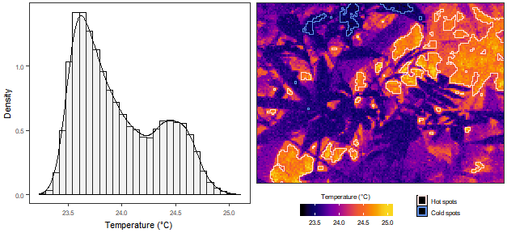

Figure 1: The output of `plot_patches` includes a histogram and the original temperature data overlaid with outlines of hot and cold spots, identified using the G* variant of the Getis-Ord local statistic.

```r
plot_patches(
    # The raw temperature data
    df = flir_stats$df,
    # The patch outlines
    patches = flir_stats$patches)
```

# References

Faye, E., Rebaudo, F., Yánez-Cajo, D., Cauvy-Fraunié, S., Dangles, O., 2016. A toolbox for studying thermal heterogeneity across spatial scales: From unmanned aerial vehicle imagery to landscape metrics. Methods in Ecology and Evolution 7, 437–446. doi:10.1111/2041-210X.12488

Getis, A., Ord, J.K., 1996. Local spatial statistics: An overview. Spatial analysis: modelling in a GIS environment 374, 261–277.

McGarigal, K., Cushman, S.A., Ene, E., 2012. FRAGSTATS v4: Spatial pattern analysis program for categorical and continuous maps. Computer software program produced by the authors at the University of Massachusetts, Amherst. Available at: [Http://www.umass.edu/landeco/research/fragstats/fragstats.html](http://www.umass.edu/landeco/research/fragstats/fragstats.html).

McGuire, J.L., Lawler, J.J., McRae, B.H., Theobald, D.M., 2016. Achieving climate connectivity in a fragmented landscape. Proceedings of the National Academy of Sciences 113, 7195–7200. doi:10.1073/pnas.1602817113

Shi, H., Wen, Z., Paull, D., Guo, M., 2016. A framework for quantifying the thermal buffering effect of microhabitats. Biological Conservation 204, 175–180. doi:10.1016/j.biocon.2016.11.006

Tattersall, G.J., 2017. Thermimage: Thermal Image Analysis. Available at: [Https://cran.R-project.org/package=Thermimage](https://CRAN.R-project.org/package=Thermimage).

VanDerWal, J., Falconi, L., Januchowski, S., Shoo, L., Storlie, C., 2014. SDMTools: Species distribution modelling tools: Tools for processing data associated with species distribution modelling exercises. Available at: [Https://cran.R-project.org/package=SDMTools](https://CRAN.R-project.org/package=SDMTools).